# Bootstrap multiple linear regression for stroke prediction

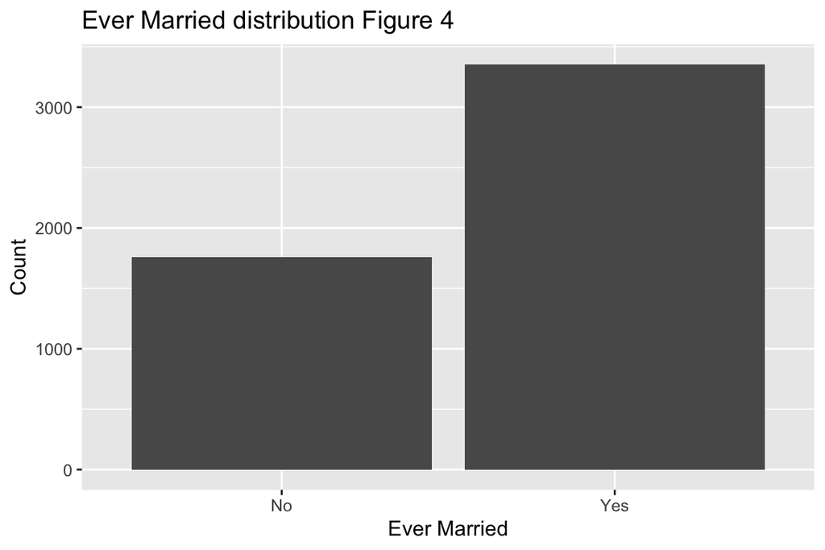

```r
ggplot(df, aes(x = ever_married)) +
  geom_bar() +
  labs(title = "Ever Married distribution Figure 4", x = "Ever Married", y = "Count")
```

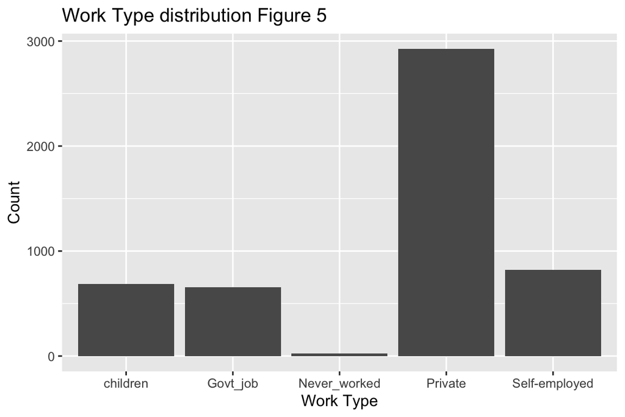

```r
ggplot(df, aes(x = work_type)) +
  geom_bar() +
  labs(title = "Work Type distribution Figure 5", x = "Work Type", y = "Count")
```

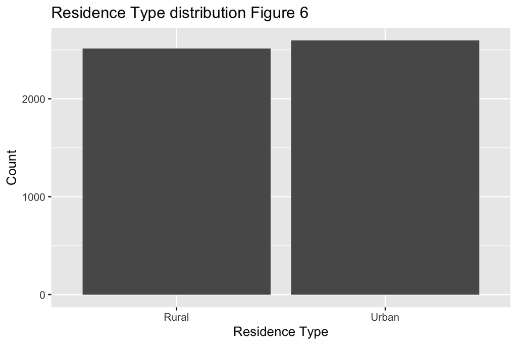

```r
ggplot(df, aes(x = Residence_type)) +
  geom_bar() +
  labs(title = "Residence Type distribution Figure 6", x = "Residence Type", y = "Count")
```

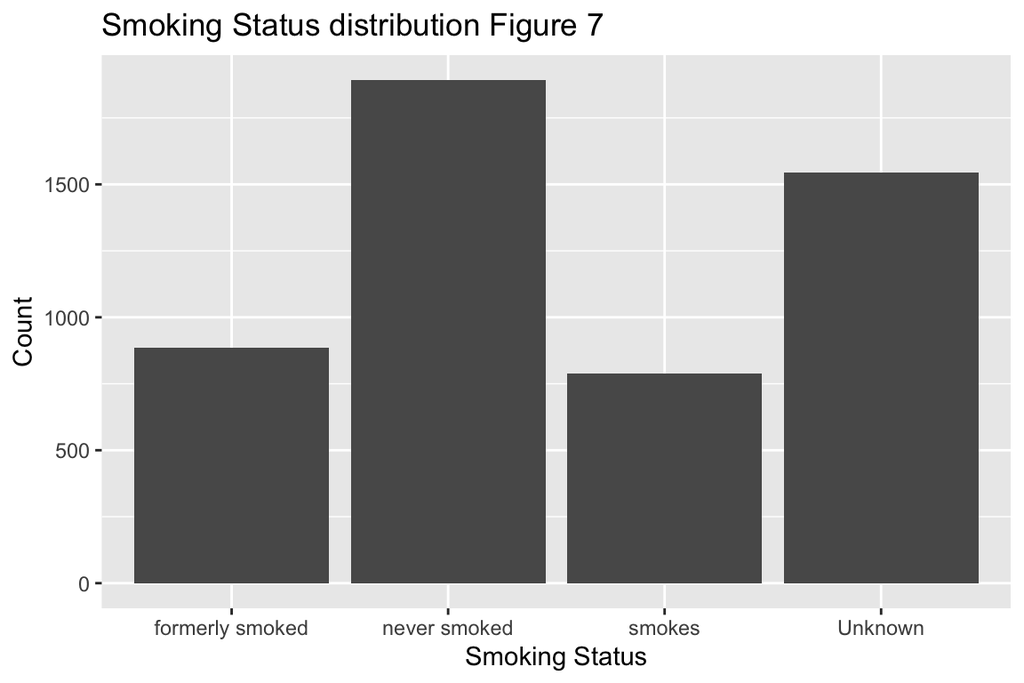

```r
ggplot(df, aes(x = smoking_status)) +
  geom_bar() +
  labs(title = "Smoking Status distribution Figure 7", x = "Smoking Status", y = "Count")
```

As we can see in figure 1 we have a relatively even distribution for male and female but we only have 1 representative of the other classification.We also see in figure 6 that there is a relatively even distribution in rural and urban residences in this study. Where figure 4 is also well represented in both groups but having more in the married classification. There are still more women in this study but it is not as far off compared to other groupings. Where in figure 2, 3 ,and 5 we see a big disparity in the groupings on those figure with Never_worked being the least represented in these figures. Where we see in figure 7 there is a close number of former smokers and smokers but there is a big gap between the never smoked and the unknown where we could not get the information on their smoking status. Though these the only group that is to small for us to do much with is the other classification with 1 observation where every other category is represented enough with Never_worked being the second closest to not being represented enough. We also see that id is a predictor variable but it is not helpful in this situation as it is just a way to tell each person apart from each other. We also Imputed the missing values in the bmi using the mice library so they all have values for our linear regression.

# 3 Model building

Now we will try and build a model using a couple of different methods backwards and forward step wise functions.

```r
predictors <- c("age", "hypertension", "heart_disease", "stroke",
                "bmi", "gender", "ever_married", "work_type",
                "Residence_type", "smoking_status")

full_model <- lm(
  avg_glucose_level ~ age + hypertension + heart_disease + stroke +
           bmi + gender + ever_married + work_type +
           Residence_type + smoking_status,
  data = stroke_predictions_imp,
)
summary(full_model)
```

```
FALSE
FALSE Call:
FALSE lm(formula = avg_glucose_level ~ age + hypertension + heart_disease +
FALSE     stroke + bmi + gender + ever_married + work_type + Residence_type +
FALSE     smoking_status, data = stroke_predictions_imp)
FALSE
FALSE Residuals:
FALSE     Min      1Q  Median      3Q     Max
FALSE -106.69  -27.96  -11.05   14.53  164.36
FALSE
FALSE Coefficients:
FALSE                             Estimate Std. Error t value Pr(>|t|)
FALSE (Intercept)                 77.55263    3.27232  23.700  < 2e-16 ***
FALSE age                          0.40194    0.04562   8.811  < 2e-16 ***
FALSE hypertension                14.11983    2.14000   6.598 4.59e-11 ***
FALSE heart_disease               18.24415    2.80183   6.512 8.16e-11 ***
FALSE stroke                      13.17657    2.91496   4.520 6.31e-06 ***
FALSE bmi                          0.73255    0.08756   8.366  < 2e-16 ***
FALSE genderMale                   4.01490    1.23724   3.245  0.00118 **
FALSE genderOther                 54.08589   43.06544   1.256  0.20921
FALSE ever_marriedYes              0.50519    1.78892   0.282  0.77765
FALSE work_typeGovt_job          -16.78960    3.17135  -5.294 1.25e-07 ***
FALSE work_typeNever_worked       -7.25067    9.38248  -0.773  0.43968
FALSE work_typePrivate           -15.16818    2.66610  -5.689 1.35e-08 ***
FALSE work_typeSelf-employed     -17.59624    3.23346  -5.442 5.52e-08 ***
FALSE Residence_typeUrban         -0.64779    1.20513  -0.538  0.59093
FALSE smoking_statusnever smoked  -0.10403    1.77984  -0.058  0.95339
FALSE smoking_statussmokes        -0.59907    2.12981  -0.281  0.77851
FALSE smoking_statusUnknown       -2.68494    2.01207  -1.334  0.18213
FALSE ---
FALSE Signif. codes:  0 '***' 0.001 '**' 0.01 '*' 0.05 '.' 0.1 ' ' 1
FALSE
FALSE Residual standard error: 43.01 on 5093 degrees of freedom
FALSE Multiple R-squared:  0.1009,  Adjusted R-squared:  0.09803
FALSE F-statistic:  35.7 on 16 and 5093 DF,  p-value: < 2.2e-16
```

```r
backward_step <- step(full_model, direction = "backward")
```

```
FALSE Start:  AIC=38458.07
FALSE avg_glucose_level ~ age + hypertension + heart_disease + stroke +
FALSE     bmi + gender + ever_married + work_type + Residence_type +
FALSE     smoking_status
FALSE
FALSE                  Df Sum of Sq     RSS   AIC
FALSE - smoking_status  3      5065 9425026 38455
FALSE - ever_married    1       148 9420109 38456
FALSE - Residence_type  1       534 9420495 38456
FALSE <none>                        9419961 38458
FALSE - gender          2     22212 9442173 38466
FALSE - stroke          1     37793 9457754 38477
FALSE - work_type       4     64498 9484459 38485
FALSE - heart_disease   1     78422 9498383 38498
FALSE - hypertension    1     80521 9500482 38500
FALSE - bmi             1    129460 9549421 38526
FALSE - age             1    143595 9563556 38533
FALSE
FALSE Step:  AIC=38454.81
FALSE avg_glucose_level ~ age + hypertension + heart_disease + stroke +
FALSE     bmi + gender + ever_married + work_type + Residence_type
FALSE
FALSE                  Df Sum of Sq     RSS   AIC
FALSE - ever_married    1       198 9425224 38453
FALSE - Residence_type  1       548 9425574 38453
FALSE <none>                        9425026 38455
FALSE - gender          2     21991 9447017 38463
FALSE - stroke          1     37631 9462657 38473
FALSE - work_type       4     60676 9485702 38480
FALSE - heart_disease   1     78509 9503535 38495
FALSE - hypertension    1     83633 9508659 38498
FALSE - bmi             1    131359 9556385 38524
FALSE - age             1    148522 9573548 38533
FALSE
FALSE Step:  AIC=38452.92
FALSE avg_glucose_level ~ age + hypertension + heart_disease + stroke +
FALSE     bmi + gender + work_type + Residence_type
FALSE
FALSE                  Df Sum of Sq     RSS   AIC
FALSE - Residence_type  1       549 9425773 38451
FALSE <none>                        9425224 38453
FALSE - gender          2     22000 9447223 38461
FALSE - stroke          1     37444 9462667 38471
FALSE - work_type       4     60962 9486186 38478
FALSE - heart_disease   1     78331 9503555 38493
FALSE - hypertension    1     83478 9508701 38496
FALSE - bmi             1    133915 9559139 38523
FALSE - age             1    201324 9626547 38559
FALSE
FALSE Step:  AIC=38451.22
FALSE avg_glucose_level ~ age + hypertension + heart_disease + stroke +
FALSE     bmi + gender + work_type
FALSE
FALSE                 Df Sum of Sq     RSS   AIC
FALSE <none>                       9425773 38451
FALSE - gender         2     22078 9447850 38459
FALSE - stroke         1     37335 9463108 38469
FALSE - work_type      4     60884 9486657 38476
FALSE - heart_disease  1     78349 9504122 38492
FALSE - hypertension   1     83672 9509445 38494
FALSE - bmi            1    133954 9559727 38521
FALSE - age            1    201059 9626832 38557
```

```r
summary(backward_step)
```

```
FALSE
FALSE Call:
FALSE lm(formula = avg_glucose_level ~ age + hypertension + heart_disease +
FALSE     stroke + bmi + gender + work_type, data = stroke_predictions_imp)
FALSE
FALSE Residuals:
FALSE     Min      1Q  Median      3Q     Max
FALSE -106.19  -27.98  -11.10   14.39  164.89
FALSE
FALSE Coefficients:
FALSE                         Estimate Std. Error t value Pr(>|t|)
FALSE (Intercept)             74.59288    2.47768  30.106  < 2e-16 ***
FALSE age                      0.41222    0.03953  10.428  < 2e-16 ***
FALSE hypertension            14.34780    2.13281   6.727 1.92e-11 ***
FALSE heart_disease           18.17695    2.79230   6.510 8.25e-11 ***
FALSE stroke                  13.07322    2.90926   4.494 7.16e-06 ***
FALSE bmi                      0.74049    0.08700   8.512  < 2e-16 ***
FALSE genderMale               3.97374    1.23283   3.223  0.00128 **
FALSE genderOther             55.04817   43.01934   1.280  0.20074
FALSE work_typeGovt_job      -15.17267    2.98867  -5.077 3.98e-07 ***
FALSE work_typeNever_worked   -6.12370    9.33198  -0.656  0.51172
FALSE work_typePrivate       -13.61576    2.46971  -5.513 3.70e-08 ***
FALSE work_typeSelf-employed -16.04846    3.08010  -5.210 1.96e-07 ***
FALSE ---
FALSE Signif. codes:  0 '***' 0.001 '**' 0.01 '*' 0.05 '.' 0.1 ' ' 1
FALSE
FALSE Residual standard error: 43 on 5098 degrees of freedom
FALSE Multiple R-squared:  0.1003,  Adjusted R-squared:  0.09835
FALSE F-statistic: 51.66 on 11 and 5098 DF,  p-value: < 2.2e-16
```

```r
# Forward
null_model <- glm(avg_glucose_level ~ 1, data = stroke_predictions_imp)
forward_step <- step(null_model, scope = formula(full_model), direction = "forward")
```

```
FALSE Start:  AIC=53472.84
FALSE avg_glucose_level ~ 1
FALSE
FALSE                  Df Deviance   AIC
FALSE + age             1  9882234 53176
FALSE + hypertension    1 10157603 53317
FALSE + bmi             1 10180379 53328
FALSE + heart_disease   1 10202058 53339
FALSE + ever_married    1 10224601 53350
FALSE + stroke          1 10294128 53385
FALSE + work_type       4 10341904 53415
FALSE + smoking_status  3 10363650 53423
FALSE + gender          2 10443769 53461
FALSE <none>              10476520 53473
FALSE + Residence_type  1 10476263 53475
FALSE
FALSE Step:  AIC=53176.43
FALSE avg_glucose_level ~ age
FALSE
FALSE                  Df Deviance   AIC
FALSE + hypertension    1  9748346 53109
FALSE + heart_disease   1  9771810 53121
FALSE + bmi             1  9788905 53130
FALSE + stroke          1  9821962 53147
FALSE + work_type       4  9832691 53159
FALSE + gender          2  9840733 53159
FALSE <none>               9882234 53176
FALSE + ever_married    1  9881366 53178
FALSE + Residence_type  1  9881508 53178
FALSE + smoking_status  3  9880593 53182
FALSE
FALSE Step:  AIC=53108.72
FALSE avg_glucose_level ~ age + hypertension
FALSE
FALSE                  Df Deviance   AIC
FALSE + heart_disease   1  9646863 53057
FALSE + bmi             1  9671544 53070
FALSE + stroke          1  9698903 53085
FALSE + gender          2  9711007 53093
FALSE + work_type       4  9706664 53095
```

[output cut: 47 more lines]

```
FALSE + gender          2  9425773 52955
FALSE <none>               9447850 52963
FALSE + Residence_type  1  9447223 52964
FALSE + ever_married    1  9447643 52965
FALSE + smoking_status  3  9442950 52966
FALSE
FALSE Step:  AIC=52954.77
FALSE avg_glucose_level ~ age + hypertension + heart_disease + bmi +
FALSE     work_type + stroke + gender
FALSE
FALSE                  Df Deviance   AIC
FALSE <none>               9425773 52955
FALSE + Residence_type  1  9425224 52956
FALSE + ever_married    1  9425574 52957
FALSE + smoking_status  3  9420644 52958
```

```r
summary(forward_step)
```

```
FALSE
FALSE Call:
FALSE glm(formula = avg_glucose_level ~ age + hypertension + heart_disease +
FALSE     bmi + work_type + stroke + gender, data = stroke_predictions_imp)
FALSE
FALSE Coefficients:
FALSE                         Estimate Std. Error t value Pr(>|t|)
FALSE (Intercept)             74.59288    2.47768  30.106  < 2e-16 ***
FALSE age                      0.41222    0.03953  10.428  < 2e-16 ***
FALSE hypertension            14.34780    2.13281   6.727 1.92e-11 ***
FALSE heart_disease           18.17695    2.79230   6.510 8.25e-11 ***
FALSE bmi                      0.74049    0.08700   8.512  < 2e-16 ***
FALSE work_typeGovt_job      -15.17267    2.98867  -5.077 3.98e-07 ***
FALSE work_typeNever_worked   -6.12370    9.33198  -0.656  0.51172
FALSE work_typePrivate       -13.61576    2.46971  -5.513 3.70e-08 ***
FALSE work_typeSelf-employed -16.04846    3.08010  -5.210 1.96e-07 ***
FALSE stroke                  13.07322    2.90926   4.494 7.16e-06 ***
FALSE genderMale               3.97374    1.23283   3.223  0.00128 **
FALSE genderOther             55.04817   43.01934   1.280  0.20074
FALSE ---
FALSE Signif. codes:  0 '***' 0.001 '**' 0.01 '*' 0.05 '.' 0.1 ' ' 1
FALSE
FALSE (Dispersion parameter for gaussian family taken to be 1848.916)
FALSE
FALSE     Null deviance: 10476520  on 5109  degrees of freedom
FALSE Residual deviance:  9425773  on 5098  degrees of freedom
FALSE AIC: 52955
FALSE
FALSE Number of Fisher Scoring iterations: 2
```

for backward and forward step wise we see they keep age, hypertension, heart_disease, bmi, work_type, stroke, and gender. Both models being the same shows that the builds are robust in making a reduced model.

```r
  kable(summary(backward_step)$coefficients,
      caption = "Backward Stepwise linear Regression Coefficients figure 8",
      align   = c("l", "c", "c", "c", "c"))
```

Backward Stepwise linear Regression Coefficients figure 8

|  | Estimate | Std. Error | t value | Pr(>\|t\|) |
| --- | --- | --- | --- | --- |
| (Intercept) | 74.592881 | 2.4776843 | 30.1058858 | 0.0000000 |
| age | 0.412217 | 0.0395296 | 10.4280511 | 0.0000000 |
| hypertension | 14.347804 | 2.1328148 | 6.7271683 | 0.0000000 |
| heart_disease | 18.176949 | 2.7922995 | 6.5096701 | 0.0000000 |
| stroke | 13.073221 | 2.9092644 | 4.4936519 | 0.0000072 |
| bmi | 0.740494 | 0.0869967 | 8.5117527 | 0.0000000 |
| genderMale | 3.973735 | 1.2328348 | 3.2232506 | 0.0012754 |
| genderOther | 55.048172 | 43.0193404 | 1.2796145 | 0.2007390 |
| work_typeGovt_job | -15.172671 | 2.9886697 | -5.0767305 | 0.0000004 |
| work_typeNever_worked | -6.123698 | 9.3319812 | -0.6562055 | 0.5117215 |
| work_typePrivate | -13.615761 | 2.4697136 | -5.5130931 | 0.0000000 |
| work_typeSelf-employed | -16.048463 | 3.0801031 | -5.2103655 | 0.0000002 |

```r
  kable(summary(full_model)$coefficients,
      caption = "Full model linear Regression Coefficients figure 9",
      align   = c("l", "c", "c", "c", "c"))
```

Full model linear Regression Coefficients figure 9

|  | Estimate | Std. Error | t value | Pr(>\|t\|) |
| --- | --- | --- | --- | --- |
| (Intercept) | 77.5526316 | 3.2723175 | 23.6996047 | 0.0000000 |
| age | 0.4019418 | 0.0456174 | 8.8111419 | 0.0000000 |
| hypertension | 14.1198271 | 2.1399995 | 6.5980517 | 0.0000000 |
| heart_disease | 18.2441455 | 2.8018318 | 6.5115062 | 0.0000000 |
| stroke | 13.1765685 | 2.9149589 | 4.5203274 | 0.0000063 |
| bmi | 0.7325523 | 0.0875606 | 8.3662356 | 0.0000000 |
| genderMale | 4.0149047 | 1.2372369 | 3.2450574 | 0.0011819 |
| genderOther | 54.0858915 | 43.0654435 | 1.2559000 | 0.2092098 |
| ever_marriedYes | 0.5051941 | 1.7889189 | 0.2824019 | 0.7776468 |
| work_typeGovt_job | -16.7895991 | 3.1713450 | -5.2941572 | 0.0000001 |
| work_typeNever_worked | -7.2506735 | 9.3824819 | -0.7727884 | 0.4396835 |
| work_typePrivate | -15.1681818 | 2.6661029 | -5.6892710 | 0.0000000 |
| work_typeSelf-employed | -17.5962431 | 3.2334559 | -5.4419307 | 0.0000001 |
| Residence_typeUrban | -0.6477863 | 1.2051333 | -0.5375226 | 0.5909302 |
| smoking_statusnever smoked | -0.1040294 | 1.7798378 | -0.0584488 | 0.9533934 |
| smoking_statussmokes | -0.5990689 | 2.1298055 | -0.2812787 | 0.7785081 |
| smoking_statusUnknown | -2.6849394 | 2.0120720 | -1.3344152 | 0.1821275 |

As we can see the above in figure 8 and 9 these are the coefficents for both the full model and the reduced model now we will do model diagnosis on these models and review if they break any of the model assumptions.

# 4 Model diognostics

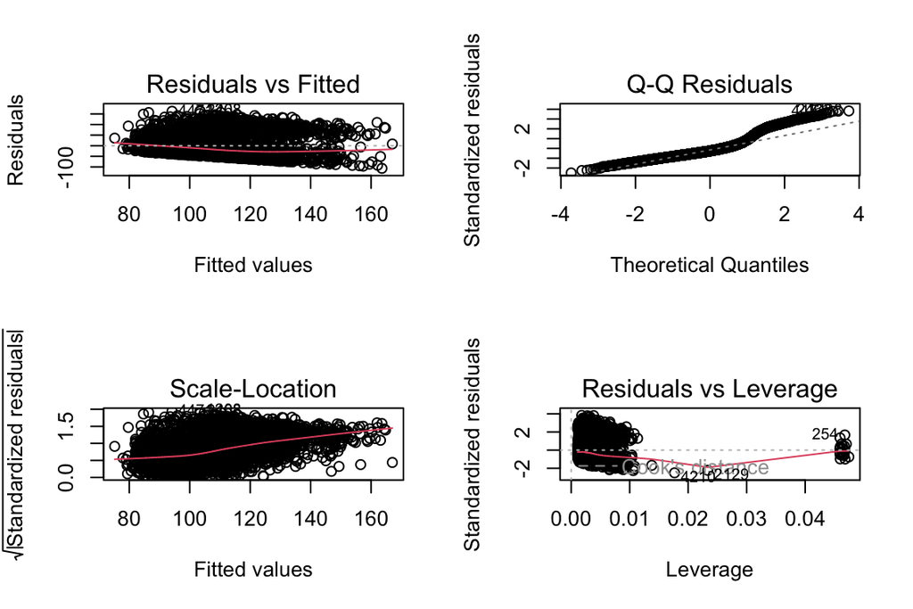

```r
par(mfrow = c(2,2))
plot(full_model)
```

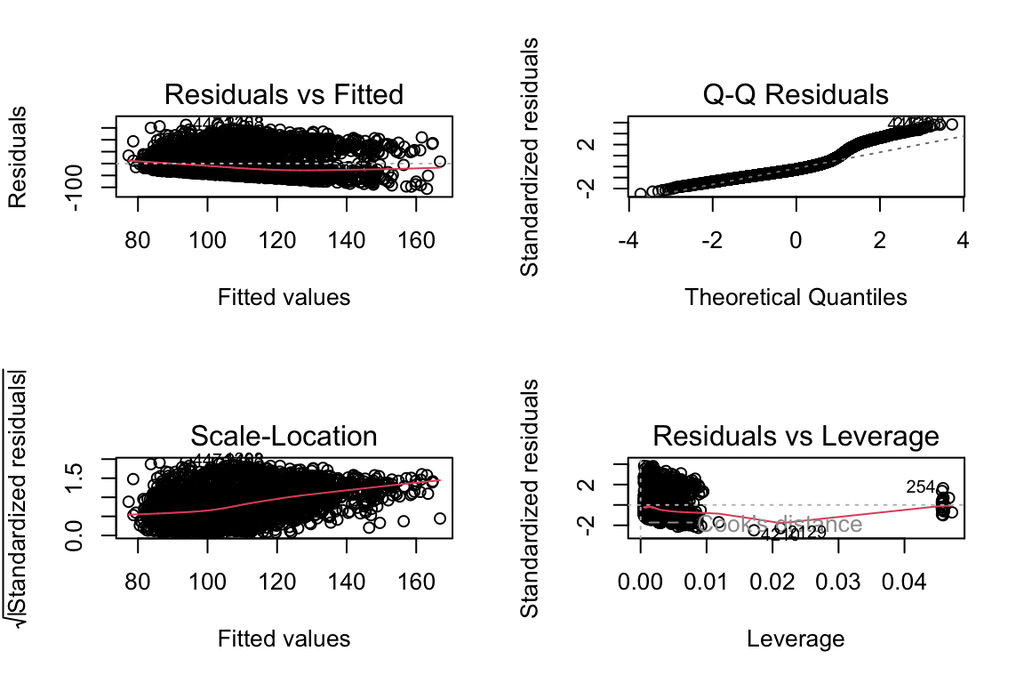

```r
par(mfrow = c(2,2))
plot(backward_step)
```